# Project for Practical Machine Learning

pd

Wednesday, May 20, 2015

## Synopsis

This course project for Practical Machine learning analyzes data from ‘Weight Lifting Exercises Dataset’ as described at http://groupware.les.inf.puc-rio.br/har and in the publication: Velloso, E.; Bulling, A.; Gellersen, H.; Ugulino, W.; Fuks, H. Qualitative Activity Recognition of Weight Lifting Exercises. Proceedings of 4th International Conference in Cooperation with SIGCHI (Augmented Human 13) . Stuttgart, Germany: ACM SIGCHI, 2013.

Using data from accelerometers on the belt, forearm, arm, and dumbell of 6 participants who performed bicep curls correctly and incorrectly in 5 different ways, the goal of the project was to predict from an observation of data from all the sensors in a single window of time, which correct or incorrect execution the dumdbell curl was being performed.

The data were downloaded into the working directory: download.file(‘https://d396qusza40orc.cloudfront.net/predmachlearn/pml-training.csv’, ‘D:/PeterD/Home Docs/Courses/Practical Machine Learning’) download.file(‘https://d396qusza40orc.cloudfront.net/predmachlearn/pml-testing.csv’)

I chose predictors based on a comment in the Discussion Forum ‘Project Data Set’ made by Edward Drake that helped to characterize the data. This comment is paraphrased as follows. The raw data was obtained from 4 sensors on the belt, glove, arm and dumbbell collected during the dumbbell curls. Each sensor captured 9 pieces of data (x,y and z component of gyros, accel and magnet), from which were calculated the roll, pitch, yaw, and total acceleration. These data total to 52 variables (4 * (9 + 4) = 52). Additional variables in the data set are statistics on these variables (e.g., kurtosis, skewness, max, min, amplitude, variance, etc.). These summary statistic variables consisted of ~97% NAs. I excluded these from the prediction model because comments on the Discussion Forum said good prediction accuracty could be obtained without them. But first I tried imputting the missing values in these variables and using all of the variables in a random forests model that ran for 16 hrs before I aborted it and went to read the Discussion Forum. Many thanks to Edward Drake and others for their comments in the forum.

The training set I used was 75% of the ‘pml-training.csv’ data. I used the remaining 25% as a validation set. The model I chose was Generalized Boosted Regression Models (Package ‘gbm’). It produced a model with an in-sample and out-of-sample accuracy of about 0.96 that correctly predicted the test cases.

## Load Libraries and Data

```r
library(AppliedPredictiveModeling); library(caret);library(ggplot2);library(grid);library(reshape);library(Rmisc);library(DMwR);library(gridExtra);library(gbm)
```

```r
dat <- read.csv('pml-training.csv', stringsAsFactors = FALSE, na.strings=c('', ' ', 'NA'))
testdat <- read.csv('pml-testing.csv', stringsAsFactors = FALSE, na.strings=c('', ' ', 'NA'))
```

## Clean Data (reduce features)

### Remove variables that are ~97% NAs

```r
# Script from Discussion Formum which cites (http://stackoverflow.com/a/23597202)
z <- colSums(is.na(dat)) # show columns with mostly NA (i.e., statistics)
z0 <- z==0               # make logical vector of columns with zero NAs
dat60 <- dat[,z0]        # selects all columns with zero NA
dat53 <- dat60[c(-1:-7)] # removes not needed columns and outcome column
```

### Divide Data Set ‘pml-training.csv’ into Training and Cross-validation Sets

```r
set.seed(123)
inTrain <- createDataPartition(y=dat53$classe, p=.75, list=FALSE)
training <- dat53[inTrain,]
testing <- dat53[-inTrain,]
```

# Exploratory Table and Plot

```r
# melt dat
mtraining <- melt(training,  id = 'classe', variable_name = 'measure')

sumry <- summarySE(mtraining, measurevar='value', groupvars=c('measure'), na.rm=TRUE)
print(sumry[,c(-5,-6)])
```

```
##                 measure     N         value           sd
## 1             roll_belt 14718  6.393999e+01  62.77034450
## 2            pitch_belt 14718  3.850537e-01  22.18656672
## 3              yaw_belt 14718 -1.197961e+01  94.85873907
## 4      total_accel_belt 14718  1.125547e+01   7.75219869
## 5          gyros_belt_x 14718 -5.602663e-03   0.20527762
## 6          gyros_belt_y 14718  3.908072e-02   0.07820768
## 7          gyros_belt_z 14718 -1.299905e-01   0.23988862
## 8          accel_belt_x 14718 -5.684196e+00  29.46817238
## 9          accel_belt_y 14718  3.000802e+01  28.59726735
## 10         accel_belt_z 14718 -7.190202e+01 100.50080168
## 11        magnet_belt_x 14718  5.508004e+01  63.64044403
## 12        magnet_belt_y 14718  5.936136e+02  36.04041011
## 13        magnet_belt_z 14718 -3.459223e+02  64.71591593
## 14             roll_arm 14718  1.770215e+01  72.66277270
```

[output cut: 38 more lines]

```r
# plot density plots for all columns
p <- ggplot(data = na.omit(mtraining), aes(x=value)) + geom_density(aes(fill=classe), alpha = 0.4) + xlim(c(-2.5,2.5)) + ylim(c(0,2))
p <- p + facet_wrap( ~ measure)
```

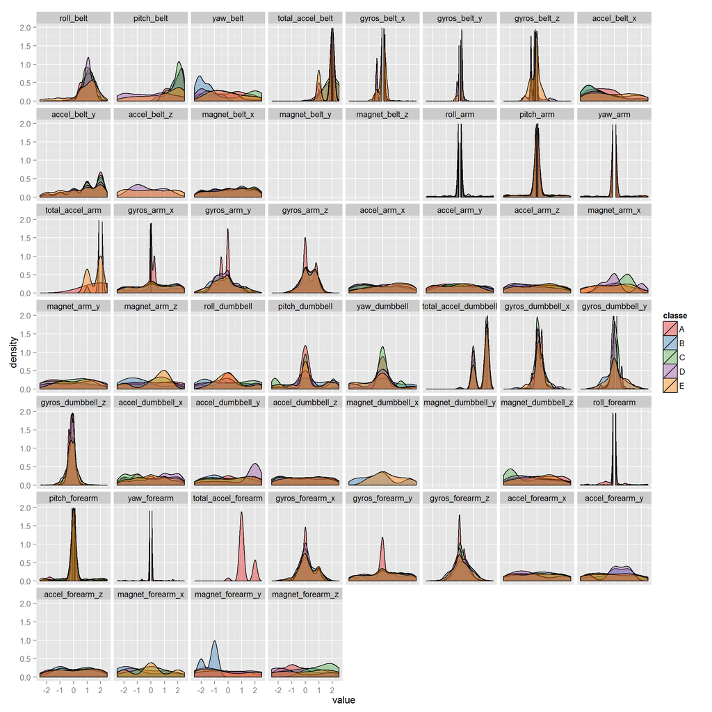

```r
p + scale_fill_brewer(palette = 'Set1')
```

# Create and Validate Model

### Train the model

```r
set.seed(123)
# gbm1 <- train(as.factor(classe) ~., data=training, method='gbm', verbose=F) # training
# saveRDS(gbm1, 'gbm1.rds')
gbm1 <- readRDS('gbm1.rds') # not running above lines to save time
print(gbm1)
```

```
## Stochastic Gradient Boosting
##
## 14718 samples
##    52 predictor
##     5 classes: 'A', 'B', 'C', 'D', 'E'
##
## No pre-processing
## Resampling: Bootstrapped (25 reps)
##
## Summary of sample sizes: 14718, 14718, 14718, 14718, 14718, 14718, ...
##
## Resampling results across tuning parameters:
##
##   interaction.depth  n.trees  Accuracy   Kappa      Accuracy SD
##   1                   50      0.7498754  0.6825378  0.006022175
##   1                  100      0.8197853  0.7717620  0.006538462
##   1                  150      0.8517976  0.8123479  0.004461078
##   2                   50      0.8532210  0.8139251  0.005631607
##   2                  100      0.9058826  0.8808448  0.003581046
##   2                  150      0.9298819  0.9112454  0.002770395
##   3                   50      0.8965165  0.8689305  0.004804739
##   3                  100      0.9401894  0.9242960  0.003051939
##   3                  150      0.9595347  0.9487886  0.002482260
##   Kappa SD
##   0.007443845
##   0.008204507
##   0.005551321
##   0.007096997
##   0.004567045
##   0.003563035
##   0.006113269
##   0.003918746
##   0.003165911
##
## Tuning parameter 'shrinkage' was held constant at a value of 0.1
##
## Tuning parameter 'n.minobsinnode' was held constant at a value of 10
## Accuracy was used to select the optimal model using  the largest value.
## The final values used for the model were n.trees = 150,
##  interaction.depth = 3, shrinkage = 0.1 and n.minobsinnode = 10.
```

##### Note the in-sample accuracy: 0.9595347

```r
gbmImp <- varImp(gbm1, scale = FALSE)
gbmImp
```

```
## gbm variable importance
##
##   only 20 most important variables shown (out of 52)
##
##                   Overall
## roll_belt          3059.7
## pitch_forearm      1524.7
## yaw_belt           1124.9
## magnet_dumbbell_z   926.4
## magnet_dumbbell_y   760.4
## roll_forearm        687.7
## magnet_belt_z       521.2
## roll_dumbbell       513.1
## gyros_belt_z        474.9
## pitch_belt          436.6
## accel_forearm_x     380.0
## gyros_dumbbell_y    260.4
## accel_forearm_z     239.2
## accel_dumbbell_y    233.4
## accel_dumbbell_x    233.1
## magnet_dumbbell_x   227.5
## magnet_forearm_z    216.3
## magnet_arm_x        197.3
## magnet_arm_z        172.0
## yaw_arm             165.8
```

### Validate the model

```r
set.seed(123)
testingpredictions <- predict(gbm1, testing) # predicting the validation set
equalPredictions <- (testingpredictions==testing$classe) # percent correct predictions
AccuracyOfPrediction<-1-(sum(equalPredictions==F)/sum(equalPredictions==T))
```

### Confusion Matrix

```r
ConfusionMatrix <- confusionMatrix(testingpredictions, testing$classe)
ConfusionMatrix
```

```
## Confusion Matrix and Statistics
##
##           Reference
## Prediction    A    B    C    D    E
##          A 1377   30    0    3    5
##          B    8  895   33    5    7
##          C    8   20  809   24    3
##          D    2    2   12  766   14
##          E    0    2    1    6  872
##
## Overall Statistics
##
##                Accuracy : 0.9623
##                  95% CI : (0.9566, 0.9674)
##     No Information Rate : 0.2845
##     P-Value [Acc > NIR] : < 2.2e-16
##
##                   Kappa : 0.9523
##  Mcnemar's Test P-Value : 9.628e-06
##
## Statistics by Class:
##
##                      Class: A Class: B Class: C Class: D Class: E
## Sensitivity            0.9871   0.9431   0.9462   0.9527   0.9678
## Specificity            0.9892   0.9866   0.9864   0.9927   0.9978
## Pos Pred Value         0.9731   0.9441   0.9363   0.9623   0.9898
## Neg Pred Value         0.9948   0.9863   0.9886   0.9907   0.9928
## Prevalence             0.2845   0.1935   0.1743   0.1639   0.1837
## Detection Rate         0.2808   0.1825   0.1650   0.1562   0.1778
## Detection Prevalence   0.2885   0.1933   0.1762   0.1623   0.1796
## Balanced Accuracy      0.9881   0.9648   0.9663   0.9727   0.9828
```

# Predict the 20 Test Cases in the Testing Data Set

```r
answers <- predict(gbm1, testdat) # predicting the test set 'pml-testing.csv'
```

#### *The predicted classes of the test set are:* B, A, B, A, A, E, D, B, A, A, B, C, B, A, E, E, A, B, B, B

### Function creates text file with a single letter (A, B, C, D, or E) indicating the predicted classe of each test case (from the instructions).

```r
pml_write_files = function(x){
                n = length(x)
                for(i in 1:n){
                        filename = paste0('problem_id_',i,'.txt')
                        write.table(x[i],file=filename,quote=FALSE,row.names=FALSE,col.names=FALSE)
                }
        }
```

### Write the files to the working directory.

```r
pml_write_files(answers)
```